# Time constants

In the circuit shown in the figure, $i=5\,$mA at $t=0$.

1. What is $V_C$ at $t=0$?
2. Find $C$ such that $i=2\,$mA at $t=20\,\mu$sec.
3. Plot $V_C(t)$ and $i(t)$.

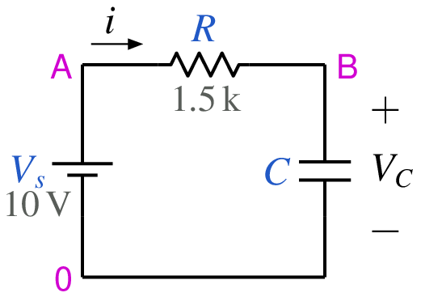

```python
from IPython.display import Image
Image(filename =r'time_constant_2_fig_1.png', width=210)
```

```python
# run this cell to view the circuit file.
%pycat time_constant_2_orig.in
```

We now replace the strings \$VC0 and \$C with the values of our choice by running the python script given below. It takes an existing circuit file `time_constant_2_orig.in` and produces a new circuit file `time_constant_2.in`, after replacing \$VC0 and \$C with the values of our choice.

```python
import gseim_calc as calc
s_VC0 = '2.5' # initial value of VC, to be changed by user
s_C = '25n' # to be changed by user
l = [
  ('$VC0', s_VC0),
  ('$C', s_C),
]
calc.replace_strings_1("time_constant_2_orig.in", "time_constant_2.in", l)
print('time_constant_2.in is ready for execution')
```

```
time_constant_2.in is ready for execution
```

**Execute the following cell to run GSEIM on time_constant_2.in.**

```python
import os
import dos_unix
# uncomment for windows:
#dos_unix.d2u("time_constant_2.in")
os.system('run_gseim time_constant_2.in')
```

```
Circuit: filename = time_constant_2.in
main: calling solve_startup
main: i_solve = 1
main: calling solve_trns
Transient simulation starts...
i=0
i=1000
GSEIM: Program completed.
```

```
0
```

The circuit file (`time_constant_2.in`) is created in the same directory as that used for launching Jupyter notebook. The last step (i.e., running `GSEIM` on `time_constant_2.in`) creates the data file `time_constant_2.dat` in the same directory. We can now use the python code below to compute and display the quantities of interest.

```
filename: time_constant_2.dat
time points at which IR crosses  2.00 mA positive slope
time points at which IR crosses  2.00 mA negative slope
   34.36 micro-sec
```

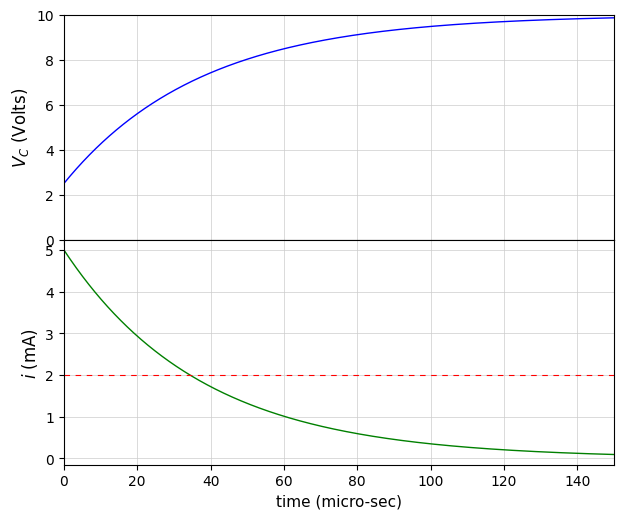

```python
import numpy as np
import matplotlib.pyplot as plt
import gseim_calc as calc
from setsize import set_size

slv = calc.slv("time_constant_2.in")

i_slv = 1
i_out = 0
filename = slv.l_filename_all[i_slv][i_out]
print('filename:', filename)
u = np.loadtxt(filename)

t = u[:, 0]
t_end = t[-1]
IR1 = 2.0e-3

IR = slv.get_array_double(i_slv, i_out, 'IR', u)
VB = slv.get_array_double(i_slv, i_out, 'VB', u)

l_cross_1, l_cross_2 = calc.cross_over_points_1(t, IR, 0.0, t_end, IR1)
print('time points at which IR crosses', "%5.2f"%(IR1*1.0e3), "mA", "positive slope")
for t1 in l_cross_1:
    print("  ", "%5.2f"%(t1*1e6), "micro-sec")
print('time points at which IR crosses', "%5.2f"%(IR1*1.0e3), "mA", "negative slope")
for t1 in l_cross_2:
    print("  ", "%5.2f"%(t1*1e6), "micro-sec")

color1='blue'
color2='green'
color3='red'

fig, ax = plt.subplots(2, sharex=False)
plt.subplots_adjust(wspace=0, hspace=0.0)

set_size(5.5, 4.5, ax[0])

for i in range(2):
    ax[i].set_xlim(left=0.0, right=t_end*1e6)
    ax[i].grid(color='#CCCCCC', linestyle='solid', linewidth=0.5)

ax[0].set_ylim(bottom=0.0, top=10.0)

ax[0].set_ylabel(r'$V_C$ (Volts)', fontsize=12)
ax[1].set_ylabel(r'$i$ (mA)',   fontsize=12)

ax[0].tick_params(labelbottom=False)

ax[0].plot(t*1e6, VB,     color=color1, linewidth=1.0, label="$V_C$")
ax[1].plot(t*1e6, IR*1e3, color=color2, linewidth=1.0, label="$i$")

ax[1].axhline(y = IR1*1e3, color = color3, linestyle = '--', linewidth=0.8, dashes=(5,5))

ax[1].set_xlabel('time (micro-sec)', fontsize=11)

#plt.tight_layout()
plt.show()
```

This notebook was contributed by **Prof. M. B. Patil**, IIT Bombay. He may be contacted at mbpatil@ee.iitb.ac.in.